# The Performance–Similarity Trade-off: A Reanalysis

Lingyu Meng

2025-08-13

# Introduction

Social decision-making often involves evaluating not only the accuracy or performance of others but also their similarity to oneself. Understanding how individuals balance these competing factors—performance and similarity—is central to theories of social learning, influence, and preference formation. **The previous study (Zhang & Gläscher, 2020) built powerful models; however, the preference in their model is merely dependent on the sequence of participants to reveal information.** In this study, we investigate social preference by modeling individual differences in how participants value informational sources that vary in both objective performance and perceived similarity. Using computational modeling, we fit participant-level parameters to quantify the relative weight assigned to each dimension, revealing the cognitive strategies that underlie social preferences.

# Methods

We used data from Zhang, L. & Gläscher, J. (2020). You can find the original data [here](https://figshare.com/articles/dataset/Stan_object_of_the_winning_model_M6b_Zhang_Gl_scher_2020_/12824309).

## Task Summary

Participants completed a six-phase social influence task. They (1) made an initial choice between two abstract options, (2) reported confidence via incentivized betting, (3) viewed others’ (4 coplayer) initial choices—selecting two preferred peers to reveal first, (4) adjusted their choice, (5) adjusted their bet, and (6) received outcome feedback based on their final choice and bet. Peer outcomes were shown.

## Modeling

For the simplicity of the model, our model is based on the m2b model from the original study. More specifically, we assume that the participants will update both the chosen value and the unchosen value. Meanwhile, the choice of coplayer will affect the choice switching based on the preference of the participant. The model is defined as follows:

Choice 1 was accounted for by the option values of option A and option B

$$\mathbb{V}_{t} =[V_{t}(A),V_{t}(B)],\tag{1}$$

where $\mathbb{V}_{t}$ indicated a two-element vector consisting of option values of A and B on trial t. Values were then converted into action probabilities using a Softmax function. On trial $t$, the action probability of choosing option A (between A and B) was defined as follows

$$P_{t}(A)=\frac{1}{1+e^{-(V_{t}(A)-V_{t}(B))}}.\tag{2}$$

For Choice 2, we modeled it as a “switch” (coded as 1) or a “stay” (coded as 0) using a logistic regression. On trial $t$, the probability of switching given the switch value was defined as follows

$$P_{t}(\text{switch} )=\Phi (V_{t}(\text{switch} )),\tag{3}$$

where $\Phi$ was the inverse logit linking function

$$\Phi (x)=\frac{1}{1+e^{-x}}.\tag{4}$$

Following the original study, we didn’t include the inverse Softmax temperature parameter $\tau$. A $\beta$ weight ($\beta_V$) was then multiplied with the values before being submitted to Softmax function with a categorical distribution, as in

$$C1_t = \text{Categorical}(\text{Softmax}(\beta_V \cdot\mathbb{V}_{t}) )
.\tag{5}$$

For the learning process, we have

$$\begin{gathered}\delta_{\text{chosen,C2} ,t} =R_{t}-V_{\text{chosen,C2}
,t}\\ \delta_{\text{unchosen,C2} ,t} =-R_{t}-V_{\text{unchosen,C2} ,t}\\
V_{\text{chosen,C2} ,t+1}=V_{\text{chosen,C2}}+\alpha
\delta_{\text{chosen,C2} ,t}\\ V_{\text{unchosen,C2}
,t+1}=V_{\text{unchosen,C2} ,t+1}+\alpha \delta_{\text{unchosen,C2}
,t}.\end{gathered}\tag{6}$$

The reward prediction error is denoted as $\delta$, and $R_{t}$ is the reward on trial $t$. The learning rate $\alpha$ is a free parameter.

The instantaneous social influence on Choice 2 is also modeled as

$$\begin{gathered}V_{t}(\text{switch} )=\beta_{\text{bias}_{\text{C2}}}
+\beta_{\text{vdiff}_{\text{C2}}} (V_{\text{chosen,C1}
,t}-V_{\text{unchosen,C1} ,t})\\ +\beta_{\text{against}}
w.\text{N}_{\text{against} ,t}\end{gathered},\tag{7}$$

where $w.\text{N}_{\text{against} ,t}$ denoted the preference-weighted amount of dissenting social information relative to each participant’s Choice 1 on trial $t$. The $\beta_{\text{bias}_{\text{C2}}}$ represent the bias to switch in second choice, where $\beta_{\text{vdiff}_{\text{C2}}}$ and $\beta_{\text{against}}$ are the free parameters that determine the influence of value difference and social information on Choice 2, respectively. For the social influence, we have

$$w.\text{N}_{\text{against,} t} =\frac{\sum_{s=1}^{K}
w_{s,t}}{\sum_{s=1}^{4} w_{s,t}} ,s=1,2,3,4,\tag{8}$$

where $s$ indicated the coplayer, $K\in \{ 0,1,2,3,4\}$ indicated the number of opposite choices from the others and $w_{s,t}$ was participants’ trial-by-trial preference weight toward the other four coplayers.

**In contrast to the original study, we calculate the consistency and accuracy of each group members considering previous 3 trials.** Therefore, we have

$$\begin{gathered}\text{acc}_{s,t} =\frac{1}{3} \sum_{\tau =t-3}^{t-1}
\text{win}_{s,\tau} ,t>3\\ \text{con}_{s,t} =\frac{1}{3} \sum_{\tau
=t-3}^{t-1} \text{sam}_{s,\tau} ,t>3\\ \text{win}_{s,t}
=\begin{cases}1&\text{if} \ R_{s,t}>0\\ 0&\text{if}
\ R_{s,t}=0\end{cases}\\ \text{sam}_{s,t} =\begin{cases}1&\text{if}
\ \text{C2}_{s,t} =\text{C2}_{t}\\ 0&\text{if} \ \text{C2}_{s,t}
\neq \text{C2}_{t}\end{cases},\end{gathered}\tag{9}$$

where $\text{C2}_{s,t}$ indicated the choice 2 of coplayer $s$ on trial $t$, and $\text{C2}_{t}$ indicated the choice 2 of participant on trial $t$. For the first three trials, we set

$$\begin{gathered}\text{acc}_{s,1} =0\\ \text{acc}_{s,t} =\frac{1}{t-1}
\sum_{\tau =1}^{t-1} \text{win}_{s,\tau}
,0<t<4\end{gathered}\tag{10}$$

and

$$\begin{gathered}\text{con}_{s,1} =0\\ \text{con}_{s,t} =\frac{1}{t-1}
\sum_{\tau =1}^{t-1} \text{sam}_{s,\tau}
,0<t<4.\end{gathered}\tag{11}$$

Now, we define the preference weight $w_{s,t}$ as follows

$$w_{s,t}=\omega \text{acc}_{s,t} +(1-\omega )\text{con}_{s,t} ,\omega \in
[0,1],\tag{12}$$

where $\omega$ is the weight parameter that determines the relative importance of accuracy and consistency in the participant’s preference.

There isn’t any revision on the bet model. However, the weights used in the bet model are same as the weights defined above.

## Important Assumptions

1. In the original study, participants were able to choose first and second sources of information. The preference therefore assigned based on the order of selection. In our model, we assume that this selection is irrelevant to the preference.
2. We suppose that all data are valid and there are no missing data.
3. We set weights for the first trial as 0. That means we assume that participants do not take any information from coplayers on the first trial.

# Results

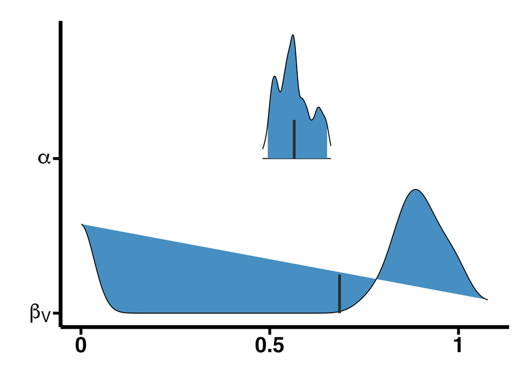

**Fig 1. Posterior density for parameters related to Choice 1**

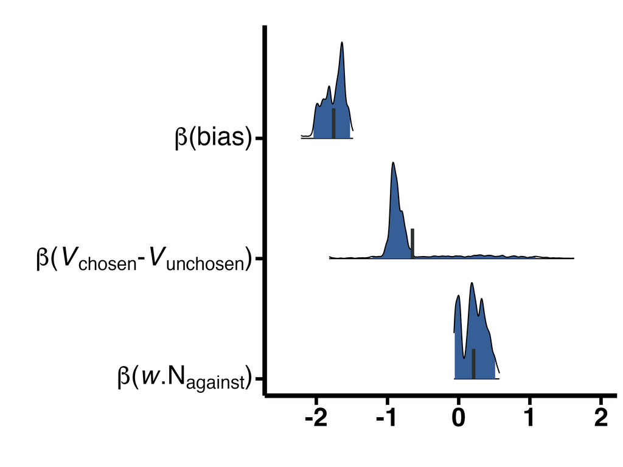

**Fig 2. Posterior density for parameters related to Choice 2**

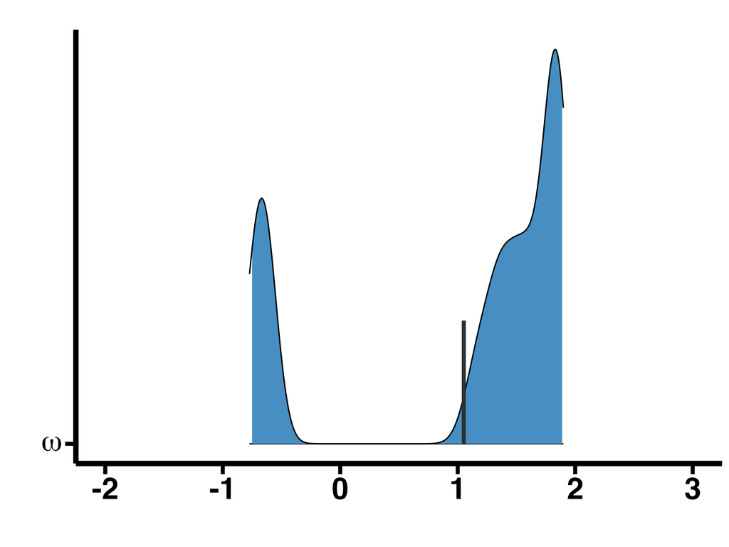

**Fig 3. Posterior density for Omega**

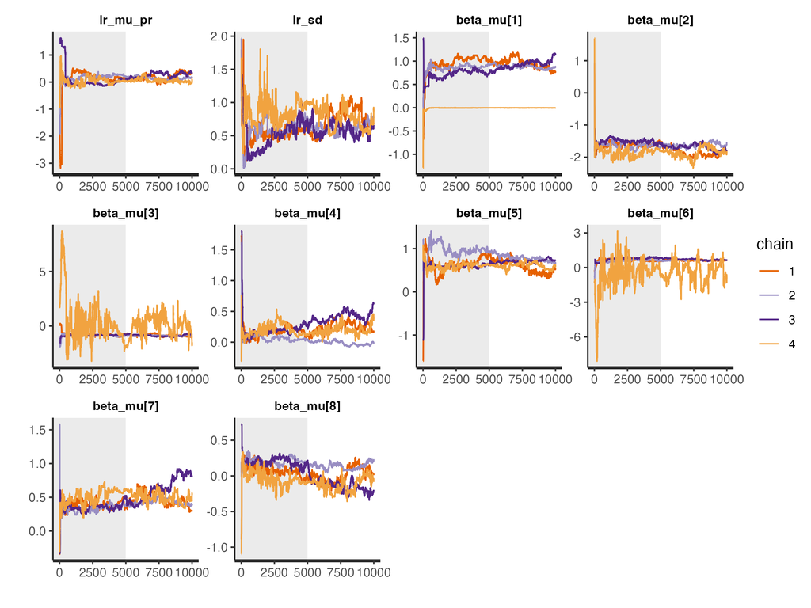

**S1 MCMC trace**

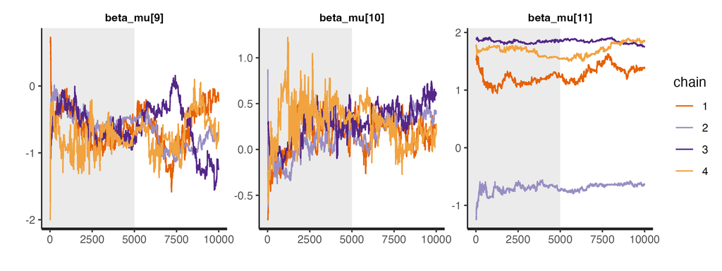

**S2 MCMC trace 2**

# Discussion

## Toward Collaboration

For investigate collaboration, our model could be extended in several ways:

1. **Incorporating more complex social dynamics**: The model could be extended to include more complex social dynamics, such as the influence of group norms or the impact of social identity on decision-making. In current model, we have considered the consistency as a type of social identity, however, that is a very simple assumption. We could also consider the social identity with experimentally manipulated social groups, such as in-group vs. out-group. That could be realized by adding reward structure to the paradigm.
2. **Incorporating more complex social networks**: The model could be extended to include more complex social networks, such as the impact of social influence on decision-making. For example, we could build a network model that uses the social influence of each participant on others as edges. By adding several phases to the task, we could investigate how the social network structure changes over time and how it affects decision-making.
3. **Incorporating more complex social preferences**: The model could be extended to include more complex social preferences, such as the impact of social norms on decision-making. For example, we could add a social norm parameter (just as bias in the current model) that captures the impact of social norms on decision-making, such as the impact of social norms on cooperation or competition. (In a different paradigm.)
4. **Incorporating more complex social interaction processes**: The current paradigm allows participants to interact with coplayers by providing information about their choices. However, the model could be extended to include more complex social interaction processes, such as communication strategies. For example, we could generate several sentences, linked to different strategies, that could be used by participants to communicate with coplayers. In a repeated economic game, we could investigate how different communication strategies affect decision-making and collaboration.

## Limitations

The current study has several limitations. First, we did not conduct a formal model comparison to determine the best-fitting model and parameter recovery. Second, due to the limitations of the memory and time constraints, we only used part of the data from the original study, which may have affected the robustness of our findings. The MCMC chains were not converged, as indicated by the Gelman-Rubin convergence diagnostic and the trace plot. Although we tried to fix the convergence issue by increasing the number of iterations and thinning, it still did not work.

# Repository

Code and figures can be found [here](https://github.com/Lingyu-Meng/performance-similarity_tradeoff_reanalysis).